# Business Statistics Mid-Term Assessment IB94X0 2022-2023 #1

2227324

# Acknowledgement

This is to certify that the work I am submitting is my own. All external references and sources are clearly acknowledged and identified within the contents. I am aware of the University of Warwick regulation concerning plagiarism and collusion.

No substantial part(s) of the work submitted here has also been submitted by me in other assessments for accredited courses of study, and I acknowledge that if this has been done an appropriate reduction in the mark I might otherwise have received will be made.

# Section 1

This analysis on the London Fire Brigade data fulfills the below mentioned asks from the service managers and local politicians:

1.1 The cost of responding to fire and false alarms

1.2 The distribution of response time by Incident Group

1.3 Summary of the special services response times

1.4 A t-test comparing the mean response time of Ealing and Greenwich

## Data Dictionary

This data dictionary is provided by the London Fire Brigade department. Features pertinent to the the analysis are described below:

| Feature | Description |
| --- | --- |
| CalYear | Calender year of the Incident Call |
| IncidentGroup | Type of Indicent - Fire, False Alarm, Specail Services |
| SpecialServiceType | Type of Special Services |
| FirstPumpArriving_AttendanceTime | The Response Time in seconds |
| Notional_Cost | Cost associated with the Incident |
| IncidentStationGround | A description of the fire station area (“Ground”) where the incident happened |

## Read London Fire Brigade Data

```r
# reading the data in r environment

fire_data <- read_csv("London_Fire_data.csv", guess_max = 10000)
# Note - no. of rows and columns imported are checked against the csv file
```

# Assumptions

Please note below assumptions made for the analysis:

1. Assuming ‘Time-Period’ refers to the Year based calculation.
2. As evident from the data, date ranges from 01-01-2019 to 31-01-2022(DD-MM-YYYY). In other words, data for Year 2022 is incomplete.
3. For ask 1.1, the cost trends are obtained at the yearly level.
4. While analysing the cost of fire alarms, special services are not considered in 1.1.
5. In the provided .csv file, the Notional Cost column name had an issue of special characters. This issue is resolved by renaming the column name to ‘Notional_Cost’ prior to uploading the file in r environment.

```r
# time period check
fire_data %>%
  summarize(min = min(CalYear), max = max(CalYear))
```

```
## # A tibble: 1 × 2
##     min   max
##   <dbl> <dbl>
## 1  2019  2022
```

```r
# unique descriptions in IncidentGroup

distinct(fire_data, IncidentGroup)
```

```
## # A tibble: 3 × 1
##   IncidentGroup
##   <chr>
## 1 Special Service
## 2 Fire
## 3 False Alarm
```

## 1.1 The cost of responding to Fire and False alarms

### Step 1.1.1 - Calculating Total and Mean cost trends at the yearly level

```r
# Total and Mean fire cost by year

# with comma separator
fire_cost_comma <- fire_data %>%
  filter(IncidentGroup == 'Fire') %>%
  group_by(CalYear) %>%
  summarize(Total_fire_cost = formatC(sum(Notional_Cost, na.rm = TRUE),format="f", big.mark = ",",  digits=0 ),
            Mean_fire_cost = mean(Notional_Cost, na.rm = TRUE))

# without comma separator
fire_cost <- fire_data %>%
  filter(IncidentGroup == 'Fire') %>%
  group_by(CalYear) %>%
  summarize(Total_fire_cost = sum(Notional_Cost, na.rm = TRUE),
            Mean_fire_cost = mean(Notional_Cost, na.rm = TRUE))

# false alarm cost by year

# with comma separator
false_cost_comma <- fire_data %>%
  filter(IncidentGroup == 'False Alarm') %>%
  group_by(CalYear) %>%
  summarize(Total_false_cost = formatC(sum(Notional_Cost, na.rm = TRUE),format="f", big.mark = ",",  digits=0 ),
            Mean_false_cost = mean(Notional_Cost, na.rm = TRUE))

# without comma separator
false_cost <- fire_data %>%
  filter(IncidentGroup == 'False Alarm') %>%
  group_by(CalYear) %>%
  summarize(Total_false_cost = sum(Notional_Cost, na.rm = TRUE),
            Mean_false_cost = mean(Notional_Cost, na.rm = TRUE))

# combined fire and flase alarm summary into one table

cost_summary_comma <- inner_join(fire_cost_comma,false_cost_comma,by = "CalYear")

cost_summary <- inner_join(fire_cost,false_cost,by = "CalYear")
#cost_summary

Total_cost_summary_comma <- cost_summary_comma %>%
  select(CalYear,Total_fire_cost,Total_false_cost)

#Total_cost_summary_comma

Total_cost_summary <- cost_summary %>%
  select(CalYear,Total_fire_cost,Total_false_cost)

#Total_cost_summary


Mean_cost_summary <- cost_summary %>%
  select(CalYear,Mean_fire_cost,Mean_false_cost)

#Mean_cost_summary
```

```r
# Final Total and Mean Cost Summary

cost_summary_comma %>%
  kbl(caption = "Table 1. Total and Mean Cost ( in £) of responding to Fire and False alarms",
      col.names = c("Year","Total Fire Cost (£)","Mean Fire Cost (£)","Total False Cost (£)","Mean False Cost (£)")) %>%
  kable_styling(position = "center")
```

Table 1. Total and Mean Cost ( in £) of responding to Fire and False alarms

| Year | Total Fire Cost (£) | Mean Fire Cost (£) | Total False Cost (£) | Mean False Cost (£) |
| --- | --- | --- | --- | --- |
| 2019 | 15,116,553 | 841.3042 | 19,884,186 | 369.1280 |
| 2020 | 14,073,027 | 809.5856 | 19,025,186 | 379.9642 |
| 2021 | 12,987,532 | 871.7049 | 20,549,464 | 385.5941 |
| 2022 | 882,464 | 777.5013 | 1,790,976 | 385.8199 |

### Step 1.1.2 - Coverting above tables from wide format to long format to aid visualization

```r
Total_cost_long <- gather(Total_cost_summary, key="measure", value="value", c("Total_fire_cost","Total_false_cost"))

Total_cost_long
```

```
## # A tibble: 8 × 3
##   CalYear measure             value
##     <dbl> <chr>               <dbl>
## 1    2019 Total_fire_cost  15116553
## 2    2020 Total_fire_cost  14073027
## 3    2021 Total_fire_cost  12987532
## 4    2022 Total_fire_cost    882464
## 5    2019 Total_false_cost 19884186
## 6    2020 Total_false_cost 19025186
## 7    2021 Total_false_cost 20549464
## 8    2022 Total_false_cost  1790976
```

```r
Mean_cost_long <- gather(Mean_cost_summary, key="measure", value="value", c("Mean_fire_cost","Mean_false_cost"))

Mean_cost_long
```

```
## # A tibble: 8 × 3
##   CalYear measure         value
##     <dbl> <chr>           <dbl>
## 1    2019 Mean_fire_cost   841.
## 2    2020 Mean_fire_cost   810.
## 3    2021 Mean_fire_cost   872.
## 4    2022 Mean_fire_cost   778.
## 5    2019 Mean_false_cost  369.
## 6    2020 Mean_false_cost  380.
## 7    2021 Mean_false_cost  386.
## 8    2022 Mean_false_cost  386.
```

### Step 1.1.3 - Visualizing the Total Cost trends for Fire and False alarm

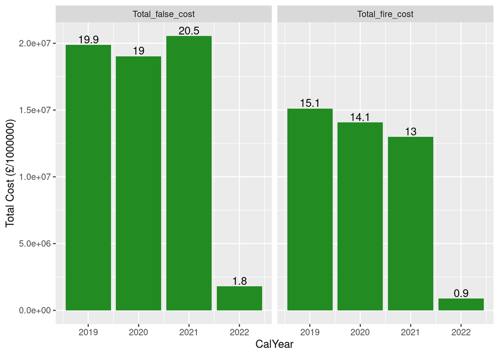

```r
# By Year - Total cost trends

total_cost_trends <- ggplot(Total_cost_long, aes(x=CalYear, y=value))+
  geom_bar(stat='identity',fill="forest green")+
  ylab("Total Cost (£/1000000)")+
  facet_wrap(~measure)+
  geom_text(aes(label = round(value/1000000,1)), vjust = -0.2, colour = 'black')

total_cost_trends
```

### Step 1.1.4 - Visualizing the Mean Cost trends for Fire and False alarm

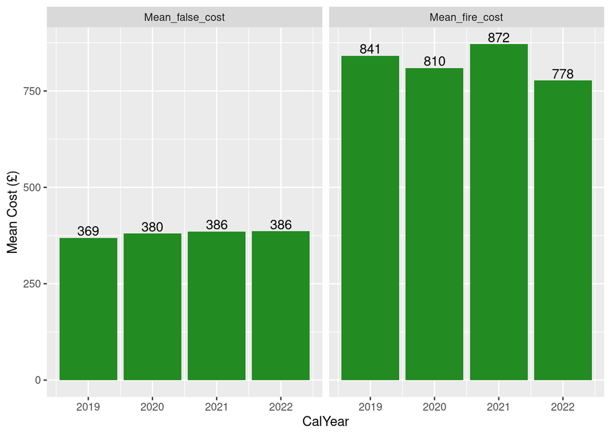

```r
# By Year - mean cost trends

mean_cost_trends <- ggplot(Mean_cost_long, aes(x=CalYear, y=value))+
  geom_bar(stat='identity',fill="forest green")+
  ylab("Mean Cost (£)")+
  facet_wrap(~measure)+
  geom_text(aes(label = round(value,0)), vjust = -0.2, colour = 'black')

mean_cost_trends
```

## 1.2 The distribution of response time by Incident Group

### Step 1.2.1 Fequency distribution of the response time for all incident groups

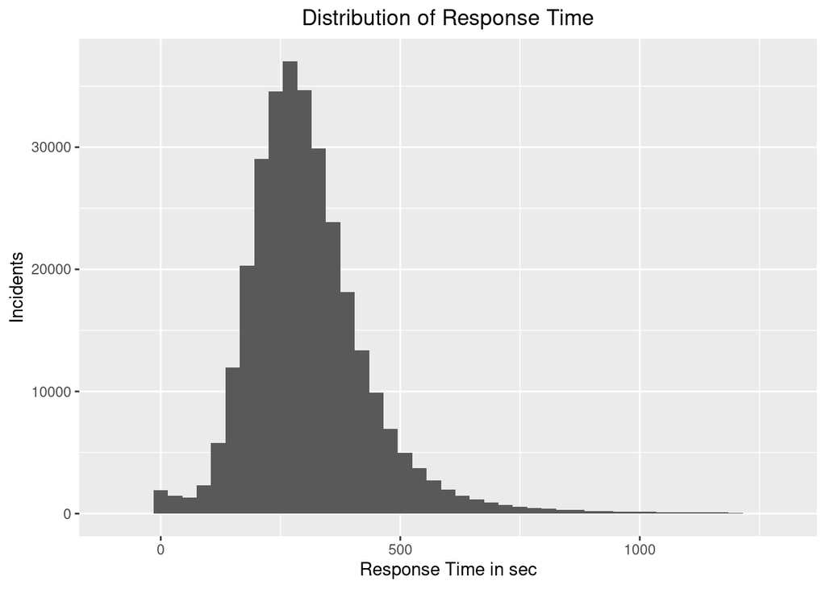

```r
# Filtering the data where FirstPumpArriving_AttendanceTime is not NA

inc_resp_df <- fire_data %>%
  filter(is.na(FirstPumpArriving_AttendanceTime) != TRUE) %>%
  select(IncidentGroup,FirstPumpArriving_AttendanceTime)

# visualisation showing response times

resp_time_freq <- ggplot(inc_resp_df, aes(x = FirstPumpArriving_AttendanceTime)) +
  geom_histogram(binwidth = 30)+
  ggtitle("Distribution of Response Time")+
  xlab("Response Time in sec") + ylab("Incidents")+
  theme(plot.title = element_text(hjust = 0.5))+
  xlim(-100, 1300)

resp_time_freq
```

### Step 1.2.2 Distribution of Response Time by Incident Group

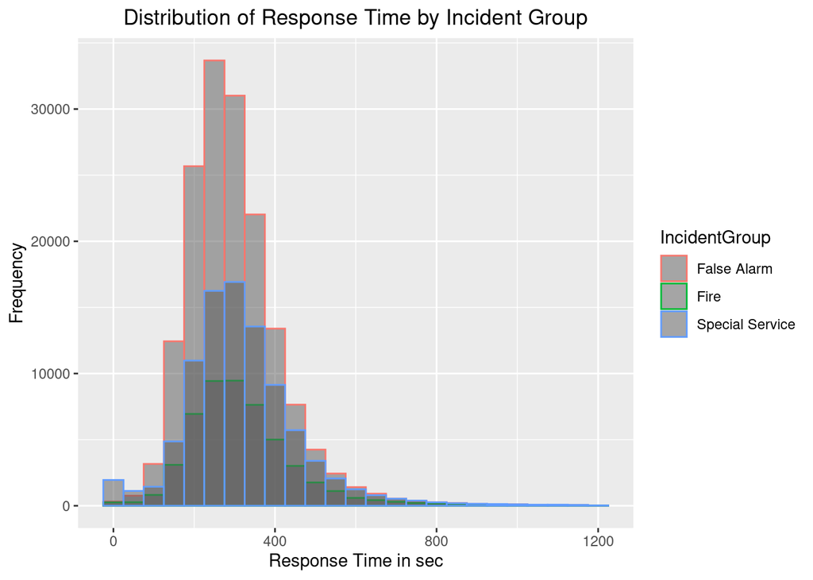

```r
# Summarizing the data by the incident group

inc_resp <- fire_data %>%
  filter(is.na(FirstPumpArriving_AttendanceTime) != TRUE) %>%
  select(IncidentGroup,FirstPumpArriving_AttendanceTime) %>%
  group_by(IncidentGroup) %>%
  summarize(response_time = sum(FirstPumpArriving_AttendanceTime))

# Distribution of Response Time by Incident Group

resp_incgrp_comp <- ggplot(inc_resp_df, aes(x = FirstPumpArriving_AttendanceTime, colour = IncidentGroup))+
  geom_histogram(binwidth = 50,position = "identity", alpha = 0.5)+
  ggtitle("Distribution of Response Time by Incident Group")+
  theme(plot.title = element_text(hjust = 0.5))+
  xlab("Response Time in sec") + ylab("Frequency")

resp_incgrp_comp
```

## 1.3 Summary of the special service response times

### Assumptions:

1. There are special services for which descriptions are not available reported under ‘Not_Available’ category
2. FirstPumpArriving_AttendanceTime having non NA values are retained for percentile calculation

### Step 1.3.1 Creating the special services data frame

```r
spec_svc_df <- fire_data %>%
  filter(IncidentGroup == 'Special Service',is.na(FirstPumpArriving_AttendanceTime) != TRUE) %>%
  select(SpecialServiceType,FirstPumpArriving_AttendanceTime) %>%
  mutate(SpecSvcDesc_NA = ifelse(is.na(SpecialServiceType == TRUE),"Not_Available",SpecialServiceType))


# checking the unique SpecialServiceType descriptions in the above df

spec_svc_desc <- distinct(spec_svc_df,SpecSvcDesc_NA)
# there are 21 types of description
```

### Step 1.3.2 Frequency, mean, 10th and 90th percentile of response type for each special service type

```r
spec_svc_summary <- spec_svc_df %>%
  group_by(SpecSvcDesc_NA) %>%
  summarize(spec_svc_count =formatC ( n(), format="f", big.mark = ",",  digits=0 ),
            mean_resp_time = mean(FirstPumpArriving_AttendanceTime, na.rm = TRUE),
            Per_10th = quantile(FirstPumpArriving_AttendanceTime,c(0.1)),
            Per_90th = quantile(FirstPumpArriving_AttendanceTime,c(0.9))) %>%
  arrange(SpecSvcDesc_NA)

spec_svc_summary %>%
  kbl(caption = "Table 3. Special Services Summary",
      col.names = c("Special Service","Frequency","Mean Response Time (in sec)","10 Percentile","90 Percentile") ) %>%
  kable_styling()
```

Table 3. Special Services Summary

| Special Service | Frequency | Mean Response Time (in sec) | 10 Percentile | 90 Percentile |
| --- | --- | --- | --- | --- |
| Advice Only | 1,817 | 319.9488 | 188.0 | 462.4 |
| Animal assistance incidents | 2,157 | 341.1734 | 190.0 | 517.4 |
| Assist other agencies | 4,339 | 316.7923 | 182.0 | 462.0 |
| Effecting entry/exit | 23,300 | 317.1222 | 182.0 | 470.0 |
| Evacuation (no fire) | 656 | 326.8674 | 192.5 | 473.5 |
| Flooding | 20,428 | 327.9579 | 191.0 | 485.0 |
| Hazardous Materials incident | 2,518 | 315.5540 | 185.0 | 463.3 |
| Lift Release | 4,506 | 306.5863 | 178.0 | 450.0 |
| Making Safe (not RTC) | 3,344 | 321.3433 | 177.0 | 494.0 |
| Medical Incident | 2,080 | 222.1591 | 8.0 | 433.0 |
| No action (not false alarm) | 7,572 | 327.6458 | 188.0 | 485.0 |
| Not_Available | 1 | 169.0000 | 169.0 | 169.0 |
| Other rescue/release of persons | 1,196 | 330.7826 | 190.5 | 482.0 |
| Other Transport incident | 858 | 317.6702 | 150.7 | 491.0 |
| Removal of objects from people | 1,526 | 207.8480 | 7.0 | 456.0 |
| Rescue or evacuation from water | 160 | 324.2250 | 175.9 | 483.7 |
| RTC | 12,077 | 318.1476 | 157.0 | 500.0 |
| Spills and Leaks (not RTC) | 2,043 | 350.3152 | 195.2 | 530.0 |
| Stand By | 154 | 309.3117 | 164.9 | 471.8 |
| Suicide/attempts | 707 | 322.8953 | 181.0 | 482.0 |
| Water provision | 1 | 245.0000 | 245.0 | 245.0 |

## 1.4 A t-test comparing the mean response time of Ealing and Greenwich

### Section 1.4.1 T-Test

#### Assumption - Data for Ealing and Greenwich grounds is extracted based IncidentStationGround column

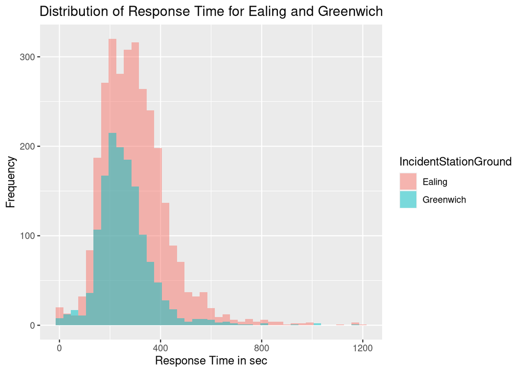

```r
# df creation for t test

t_test_df <- fire_data %>%
  filter((IncidentStationGround == 'Ealing' | IncidentStationGround == 'Greenwich') & is.na(FirstPumpArriving_AttendanceTime)!= TRUE) %>%
  select(IncidentStationGround,FirstPumpArriving_AttendanceTime)

# Calculating mean, sd and freq for the Ealing and Greenwich

eal_green_summary <- t_test_df %>%
  group_by(IncidentStationGround) %>%
  summarize(mean = mean(FirstPumpArriving_AttendanceTime, na.rm = TRUE),
            sd = sd(FirstPumpArriving_AttendanceTime, na.rm = TRUE),
            n = n())

# ggplot to visualize the normal distribution
ealing_green_histogram <- ggplot(t_test_df, aes(x = FirstPumpArriving_AttendanceTime,fill = IncidentStationGround))+
  geom_histogram(binwidth = 30, position = "identity", alpha = 0.5)+
  ggtitle("Distribution of Response Time for Ealing and Greenwich")+
  xlab("Response Time in sec") + ylab("Frequency")+
  theme(plot.title = element_text(hjust = 0.5))

ealing_green_histogram
```

```r
# two sample t-test

t.test(FirstPumpArriving_AttendanceTime~IncidentStationGround, data=t_test_df)
```

```
##
##  Welch Two Sample t-test
##
## data:  FirstPumpArriving_AttendanceTime by IncidentStationGround
## t = 10.634, df = 3359.6, p-value < 2.2e-16
## alternative hypothesis: true difference in means between group Ealing and group Greenwich is not equal to 0
## 95 percent confidence interval:
##  32.57658 47.30520
## sample estimates:
##    mean in group Ealing mean in group Greenwich
##                299.8281                259.8872
```

### Section 1.4.2 Estimations Approach

```r
# Utilising General Linear model for estimations

# 1. Mean response time for each ground stations

estimate_resp_time <- lm(FirstPumpArriving_AttendanceTime~IncidentStationGround, data=t_test_df)
(  estimate_resp_time_emm <- emmeans(estimate_resp_time, ~IncidentStationGround)  )
```

```
##  IncidentStationGround emmean   SE   df lower.CL upper.CL
##  Ealing                   300 2.28 4461      295      304
##  Greenwich                260 3.33 4461      253      266
##
## Confidence level used: 0.95
```

```r
# 2. Mean difference response time

(  estimate_resp_time_contrast <- confint(pairs(estimate_resp_time_emm))  )
```

```
##  contrast           estimate   SE   df lower.CL upper.CL
##  Ealing - Greenwich     39.9 4.04 4461       32     47.9
##
## Confidence level used: 0.95
```

# Section 2

This part of the report explains the analyses request by the panel members of the London Fire Brigade board.

## 2.1 The cost of responding to fires and false alarms

This section summarises the Total cost and Mean cost of responding to the fire and false alarms

Table 1. Total Cost ( in £) of responding to Fire and False alarms

| Year | Total Fire Cost (£) | Total False Cost (£) |
| --- | --- | --- |
| 2019 | 15,116,553 | 19,884,186 |
| 2020 | 14,073,027 | 19,025,186 |
| 2021 | 12,987,532 | 20,549,464 |
| 2022 | 882,464 | 1,790,976 |

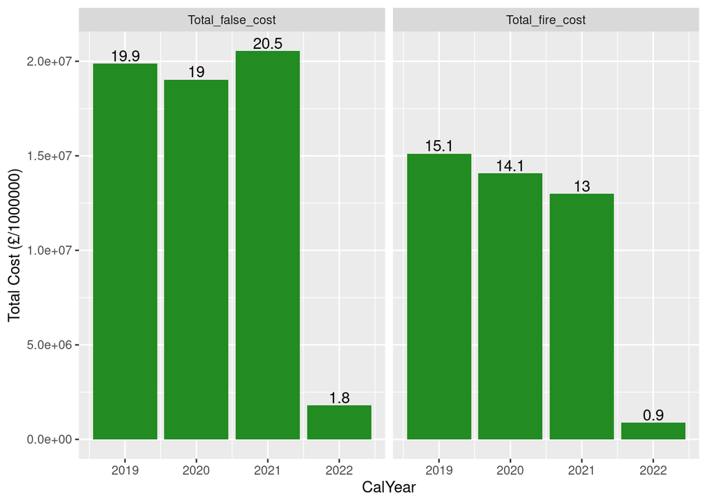

Table 2. Mean Cost ( in £) of responding to Fire and False alarms

| Year | Mean Fire Cost (£) | Mean False Cost (£) |
| --- | --- | --- |
| 2019 | 841.3042 | 369.1280 |
| 2020 | 809.5856 | 379.9642 |
| 2021 | 871.7049 | 385.5941 |
| 2022 | 777.5013 | 385.8199 |

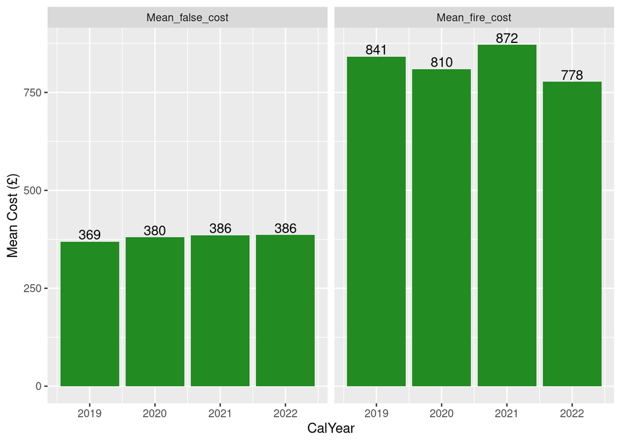

As evident from above data Tables ( 1 and 2) and Bar charts, the total cost of fire decreases on a YoY basis*. However, the mean fire cost does not show any such trend. On the other hand, the total and mean cost of false alarms remains within a range on a YoY basis.

** Please refer to assumption 2 while interpreting YoY cost trends.

## 2.2 The distribution of response time by Incident Group

This section displays the requested visualisations concerning the response time.

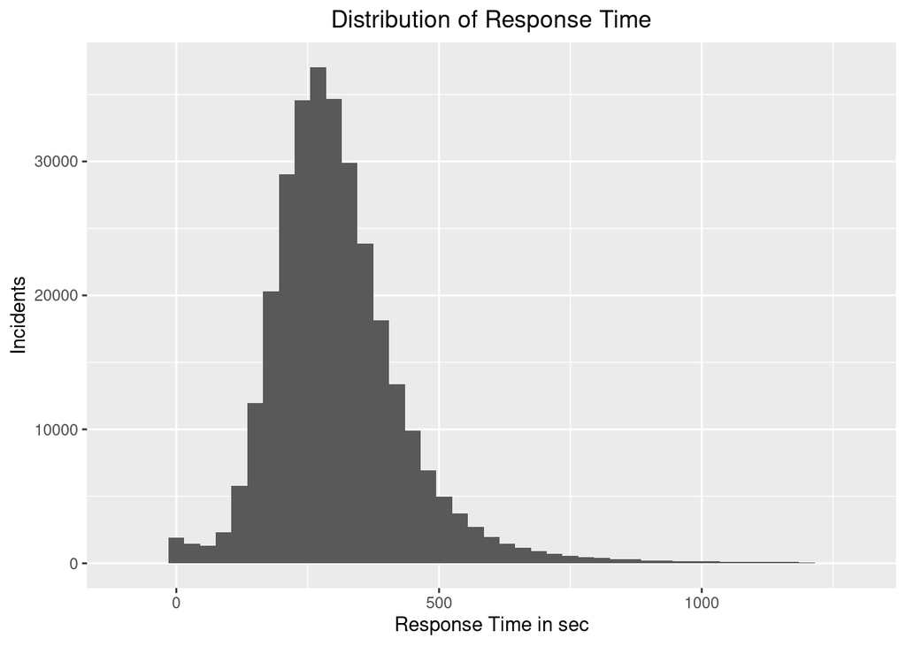

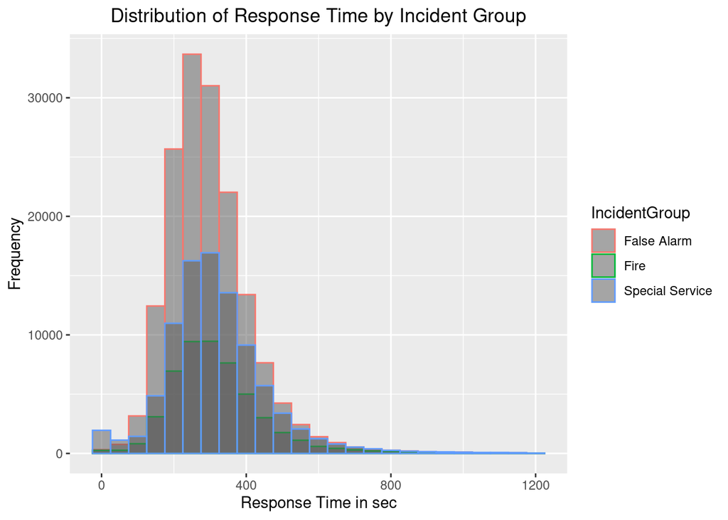

## 2.3 Summary of the special service response times

This section summarises the services rendered to special incident groups.

Table 3. Special Services Summary

| Special Service | Frequency | Mean Response Time (in sec) | 10 Percentile | 90 Percentile |
| --- | --- | --- | --- | --- |
| Advice Only | 1,817 | 319.9488 | 188.0 | 462.4 |
| Animal assistance incidents | 2,157 | 341.1734 | 190.0 | 517.4 |
| Assist other agencies | 4,339 | 316.7923 | 182.0 | 462.0 |
| Effecting entry/exit | 23,300 | 317.1222 | 182.0 | 470.0 |
| Evacuation (no fire) | 656 | 326.8674 | 192.5 | 473.5 |
| Flooding | 20,428 | 327.9579 | 191.0 | 485.0 |
| Hazardous Materials incident | 2,518 | 315.5540 | 185.0 | 463.3 |
| Lift Release | 4,506 | 306.5863 | 178.0 | 450.0 |
| Making Safe (not RTC) | 3,344 | 321.3433 | 177.0 | 494.0 |
| Medical Incident | 2,080 | 222.1591 | 8.0 | 433.0 |
| No action (not false alarm) | 7,572 | 327.6458 | 188.0 | 485.0 |
| Not_Available | 1 | 169.0000 | 169.0 | 169.0 |
| Other rescue/release of persons | 1,196 | 330.7826 | 190.5 | 482.0 |
| Other Transport incident | 858 | 317.6702 | 150.7 | 491.0 |
| Removal of objects from people | 1,526 | 207.8480 | 7.0 | 456.0 |
| Rescue or evacuation from water | 160 | 324.2250 | 175.9 | 483.7 |
| RTC | 12,077 | 318.1476 | 157.0 | 500.0 |
| Spills and Leaks (not RTC) | 2,043 | 350.3152 | 195.2 | 530.0 |
| Stand By | 154 | 309.3117 | 164.9 | 471.8 |
| Suicide/attempts | 707 | 322.8953 | 181.0 | 482.0 |
| Water provision | 1 | 245.0000 | 245.0 | 245.0 |

## 2.4 A t-test comparing the mean response time of Ealing and Greenwich

### 2.4.1 T-Test Summary

To compare the mean response time of Ealing and Greenwich, the independent-sample t-test is performed. Table 4 below shows summary statistics - mean, standard deviation, and frequency. In addition, normal distributions are also obtained to gauge the skewness of the data.

Table 4. Summary Statistics of Ealing and Greenwich

| Incident Ground | Mean Response Time (in sec) | Standard Deviation | n |
| --- | --- | --- | --- |
| Ealing | 299.8281 | 133.0527 | 3036 |
| Greenwich | 259.8872 | 108.6772 | 1427 |

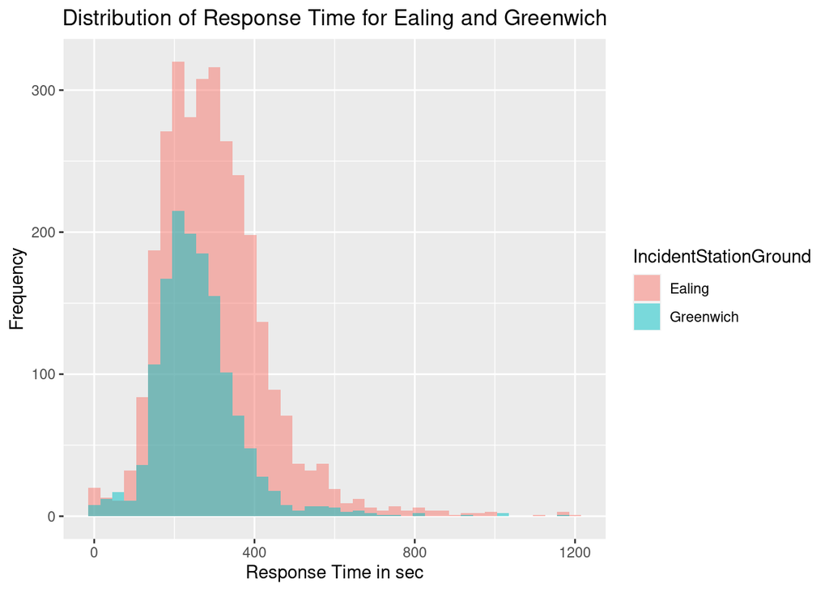

As evident from the results below of the two-sample t-test, the magnitude of p-value is very less (p<0.0001), therefore, we can safely conclude that the mean of the population from which Ealing and Greenwich are taken are very likely to be different from one another. Therefore, we can reject the Null hypothesis.

```
##
##  Welch Two Sample t-test
##
## data:  FirstPumpArriving_AttendanceTime by IncidentStationGround
## t = 10.634, df = 3359.6, p-value < 2.2e-16
## alternative hypothesis: true difference in means between group Ealing and group Greenwich is not equal to 0
## 95 percent confidence interval:
##  32.57658 47.30520
## sample estimates:
##    mean in group Ealing mean in group Greenwich
##                299.8281                259.8872
```

To conclude the results from t-test, the mean response time of Ealing is 300 seconds. The mean response time of Greenwich is 260 seconds. The mean response time of Ealing is significantly larger compared to Greenwich, Welch t(3360) = 10.63, p < 0.0001, with a difference of 40 seconds.

Above conclusions based on t-test are offered with significant caveats. The normal distributions for the concerned incident grounds are positively skewed and non-normal.Therefore, this means that the results of the t-test may be biased, and other methods are recommended to draw concrete conclusions.

### 2.4.2 Estimations Approach Summary

The figure below summarises the estimations approach of calculating the mean difference in response time of Ealing and Greenwich grounds.

The mean response time for Ealing is 300 seconds 95% CI [295–304]. The mean response time for Greenwich is 260 seconds 95% CI [253–266]. The difference is 40 seconds 95% CI [32,47.9] smaller at Greenwich compared to Ealing.

To conclude, Estimations approach is better and more reliable than NHST testing method as it provides more information rather than just a p value.

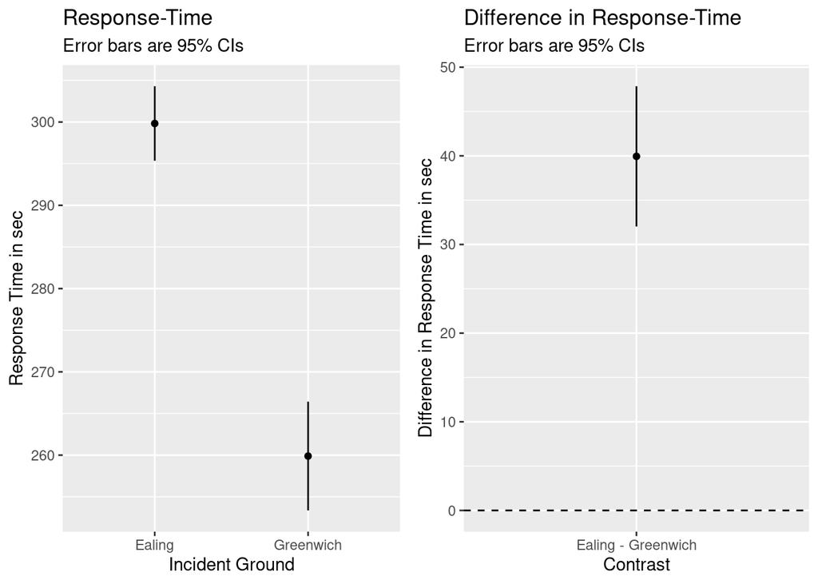